# Économétrie

LEMKHAYER Imane - YILMAZ Ilayda - MOUSALLI Hafsa

# 1 Présentation de la question de recherche

Dans ce projet, nous cherchons à répondre à la question de recherche suivante : **Quels sont les déterminants des ventes de cigares et comment les caractéristiques économiques, démographiques et les variations temporelles influencent-elles ces ventes ?**

L’objectif principal est de comprendre les principaux facteurs influençant les ventes de cigares et d’évaluer l’importance relative de chacun. Cette analyse permettra de mieux appréhender les comportements de consommation, les impacts des politiques tarifaires, et les dynamiques économiques et démographiques à travers les régions et les années.

Pour répondre à cette question, nous utilisons la base de données *cigar* et appliquons plusieurs modèles économétriques, notamment le modèle poolé, le modèle à effets fixes et le modèle à effets aléatoires. Cette approche méthodologique nous permettra de mettre en évidence les contributions respectives des facteurs économiques (prix, taxes, revenus), des caractéristiques démographiques (population) et des tendances temporelles sur les ventes de cigares.

## 1.1 Hypothèses de recherhe

- **H1 :** Une augmentation du prix moyen des cigares (*price*) réduit les ventes totales (*sales*) en raison de la sensibilité au prix des consommateurs. En effet, plus le prix est élevé, moins de consommateurs seront incités à consommer.
- **H2 :** Une population totale plus importante (*pop*) entraîne une augmentation des ventes totales, reflétant une demande agrégée plus élevée.
- **H3 :** La proportion de la population âgée de 16 ans et plus (*pop16*) a un effet positif sur les ventes, cette tranche d’âge étant plus susceptible de consommer des cigares.
- **H4 :** Une hausse du revenu national disponible (*ndi*) accroît les ventes.
- **H5 :** Une augmentation de l’indice des prix à la consommation (*cpi*) peut réduire les ventes, reflétant une diminution du pouvoir d’achat des consommateurs.
- **H6 :** La proportion de la population consommant des cigares (*pimin*) influence positivement les ventes totales.
- **H7** : Les caractéristiques géographiques influencent les ventes de cigares, par exemple, des ventes plus élevées dans les grandes villes.

# 2 Présentation des données

```r
library(plm)
data("Cigar")
```

Notre base contient 1380 observations et 9 variables.

# 3 Statistiques descriptives

Dans un premier temps, nous avons fait un code qui calcule les statistiques descriptives (minimum, moyenne, maximum, médiane, écart-type) pour toutes les variables quantitatives, à l’exception des colonnes ‘state’ et ‘year’. Puis les résultats sont affichés sous forme de tableau.

## 3.1 Fonction

```r
f <- function(data) round(c(
  Min = min(data, na.rm = TRUE),
  Mean = mean(data, na.rm = TRUE),
  Max = max(data, na.rm = TRUE),
  Median = median(data, na.rm = TRUE),
  Sd = sd(data, na.rm = TRUE)
), 3)

# Sélection des variables quantitatives sauf 'state' et 'year'
numerical_vars <- Cigar |>  select(-state, -year) |>  select_if(is.numeric)

descrstat <- apply(numerical_vars, 2, f) |> t() |> round(2)
descrstat
```

```
##           Min    Mean     Max Median      Sd
## price   23.40   68.70   201.9   52.3   41.99
## pop    319.00 4537.11 30703.3 3174.0 4828.84
## pop16  215.20 3366.62 22920.0 2315.3 3641.85
## cpi     30.60   73.60   140.3   62.9   36.53
## ndi   1322.57 7525.02 23074.0 6281.2 4747.86
## sales   53.40  123.95   297.9  121.2   30.99
## pimin   23.40   62.90   178.5   46.4   38.32
```

La fonction summary() permet d’obtenir un résumé statistique global des données avec toutes les variables cette fois ci.

```r
summary(Cigar)
```

```
##      state            year          price             pop
##  Min.   : 1.00   Min.   :63.0   Min.   : 23.40   Min.   :  319
##  1st Qu.:15.00   1st Qu.:70.0   1st Qu.: 34.77   1st Qu.: 1053
##  Median :26.50   Median :77.5   Median : 52.30   Median : 3174
##  Mean   :26.83   Mean   :77.5   Mean   : 68.70   Mean   : 4537
##  3rd Qu.:40.00   3rd Qu.:85.0   3rd Qu.: 98.10   3rd Qu.: 5280
##  Max.   :51.00   Max.   :92.0   Max.   :201.90   Max.   :30703
##      pop16              cpi             ndi            sales
##  Min.   :  215.2   Min.   : 30.6   Min.   : 1323   Min.   : 53.4
##  1st Qu.:  781.2   1st Qu.: 38.8   1st Qu.: 3328   1st Qu.:107.9
##  Median : 2315.3   Median : 62.9   Median : 6281   Median :121.2
##  Mean   : 3366.6   Mean   : 73.6   Mean   : 7525   Mean   :124.0
##  3rd Qu.: 3914.3   3rd Qu.:107.6   3rd Qu.:11024   3rd Qu.:133.2
##  Max.   :22920.0   Max.   :140.3   Max.   :23074   Max.   :297.9
##      pimin
##  Min.   : 23.40
##  1st Qu.: 31.98
##  Median : 46.40
##  Mean   : 62.90
##  3rd Qu.: 90.50
##  Max.   :178.50
```

Interpretation :

- price : le prix varie de 23,4 à 201,9, ce qui pourrait influencer la consommation de manière significative.
- cpi : on a une moyenne de 73,6, un minimum de 30,6 et un maximum de 140,3. on peut voir qu’il y a une augmentation qui reflète l’inflation au cours des années.
- ndi : on a une moyenne de 7 525, avec un maximum de 23 074. Cette variable est importante pour analyser la demande, car elle représente le pouvoir d’achat.
- sales : Varie de 53,4 à 297,9 qui pourrait refléter des différences significatives de consommation entre les États ou les années.

## 3.2 Visualisation

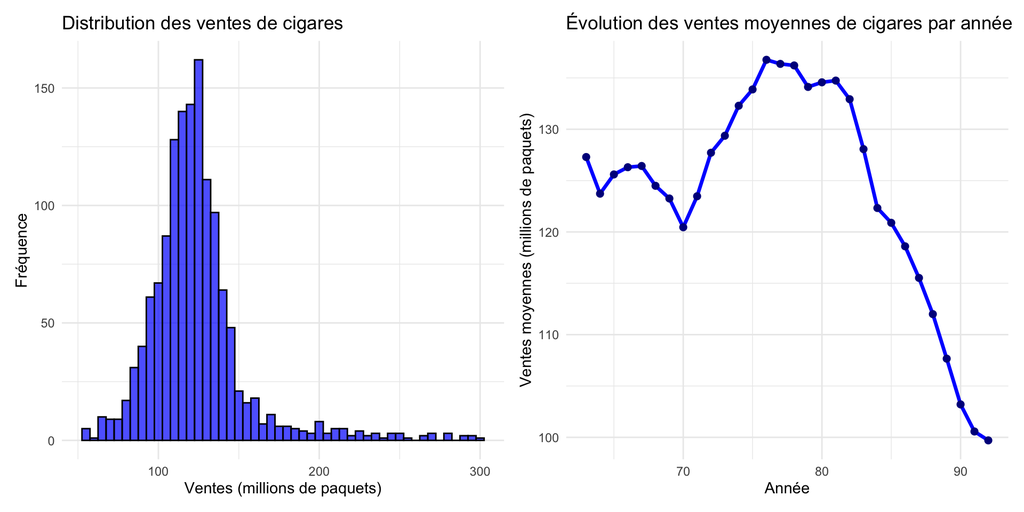

Distribution des ventes de cigares :

- On observe une distribution asymétrique à droite, ce qui signifie qu’une minorité des observations représente des ventes très élevées.
- Cela peut refléter des différences entre les États en termes de consommation.

Évolution des ventes moyennes de cigares par année :

- Le graphique montre une tendance générale : les ventes augmentent dans les années 70, atteignent un pic, puis diminuent fortement dans les années 80 et 90.
- Cette diminution peut être due à des politiques publiques (taxes) ou à un changement de comportement des consommateurs.

# 4 Présentation des différentes Modèles

## 4.1 Modèle poolé

- Le modèle Pooled OLS considère toutes les observations comme une seule entité sans distinction entre les unités temporelles et géographiques. Il ne prend pas en compte les effets fixes ou aléatoires.

```r
pooled_model <- plm(sales ~ price + pop + pop16 + cpi + ndi + pimin,
                   data = Cigar,
                   model = "pooling",
                   effect = "individual",
                   index = c("state", "year"))

summary(pooled_model)
```

```
## Pooling Model
##
## Call:
## plm(formula = sales ~ price + pop + pop16 + cpi + ndi + pimin,
##     data = Cigar, effect = "individual", model = "pooling", index = c("state",
##         "year"))
##
## Balanced Panel: n = 46, T = 30, N = 1380
##
## Residuals:
##     Min.  1st Qu.   Median  3rd Qu.     Max.
## -63.1547 -15.3291  -2.3784   9.2279 159.2068
##
## Coefficients:
##                Estimate  Std. Error  t-value  Pr(>|t|)
## (Intercept)  1.3862e+02  2.2470e+00  61.6920 < 2.2e-16 ***
## price       -1.5276e+00  1.1532e-01 -13.2466 < 2.2e-16 ***
## pop         -2.5018e-03  2.7692e-03  -0.9034   0.36645
## pop16        2.4162e-03  3.7002e-03   0.6530   0.51388
## cpi          1.4430e-01  8.1220e-02   1.7767   0.07584 .
## ndi          6.0417e-03  5.9718e-04  10.1171 < 2.2e-16 ***
## pimin        5.9477e-01  1.2745e-01   4.6667  3.36e-06 ***
## ---
## Signif. codes:  0 '***' 0.001 '**' 0.01 '*' 0.05 '.' 0.1 ' ' 1
##
## Total Sum of Squares:    1324500
## Residual Sum of Squares: 998450
## R-Squared:      0.24614
## Adj. R-Squared: 0.24285
## F-statistic: 74.7167 on 6 and 1373 DF, p-value: < 2.22e-16
```

Dans un premier temps, nous interprétons les coefficients des variables afin de comprendre leur influence sur les ventes de cigares :

- Price : Lorsqu’une augmentation de 1 dollar du prix moyen par paquet intervient, les ventes diminuent en moyenne de 1,5276 millions de paquets. Cela reflète une élasticité-prix négative, typique pour ce type de produit.
- NDI : Une hausse de 1 milliard de dollars du revenu national disponible est associée à une augmentation moyenne de 0,00604 millions de paquets vendus. Cela traduit un effet revenu positif.
- Pimin : Une augmentation de 1 % de cette proportion entraîne une hausse moyenne de 0,59 million de paquets vendus, ce qui souligne l’impact du comportement démographique sur la demande. Dans un second temps, nous examinons la p-value de chaque variable afin d’évaluer leur significativité statistique, et donc leur impact réel dans le modèle.

Dans notre cas, les variables price, ndi et pimin sont toutes significatives au seuil de 1 % , ce qui confirme leur influence importante sur les ventes. En revanche, les variables pop (taille de la population), pop16 (proportion de la population âgée de 16 ans et plus) et cpi (indice des prix à la consommation) ne sont pas significatives, ce qui suggère qu’elles n’exercent pas d’effet direct sur les ventes dans ce modèle.

**Conclusion**

L’analyse menée à partir du modèle poolé met en évidence les variables les plus influentes sur la demande de cigares.

- Le prix joue un rôle clé : son effet négatif et significatif indique qu’une augmentation du prix entraîne une baisse des ventes. Ce résultat confirme que la demande de cigares est sensible aux variations de prix.
- Le revenu national disponible a un effet positif, traduisant un pouvoir d’achat accru favorisant la consommation.
- La proportion minimale de la population consommatrice impacte aussi positivement les ventes, ce qui est logique, car une population plus encline à consommer entraîne une demande plus forte.

Enfin, la faible valeur du R² suggère que le modèle ne capture pas toutes les dimensions influençant les ventes. Parmi les variables absentes qui pourraient améliorer la précision du modèle, on peut citer :

- Le niveau de taxation sur les cigares, qui influence directement leur prix et donc leur consommation
- Le niveau d’éducation, souvent corrélé à une meilleure connaissance des risques liés au tabac, ce qui pourrait réduire la demande. En résumé, ce modèle fournit une première lecture utile des déterminants de la demande de cigares, tout en indiquant les pistes d’amélioration à explorer pour affiner l’analyse.

## 4.2 Modèle à effets fixes (Within)

- Les différences non observées entre les individus (hétérogénéité individuelle) sont corrélées avec les variables explicatives.

```r
within_model <- plm(sales ~ price + pop + pop16 + cpi + ndi + pimin - 1,
                   data = Cigar,
                   model = "within",
                   index = c("state", "year"))
summary(within_model)
```

```
## Oneway (individual) effect Within Model
##
## Call:
## plm(formula = sales ~ price + pop + pop16 + cpi + ndi + pimin -
##     1, data = Cigar, model = "within", index = c("state", "year"))
##
## Balanced Panel: n = 46, T = 30, N = 1380
##
## Residuals:
##      Min.   1st Qu.    Median   3rd Qu.      Max.
## -57.81439  -6.16269  -0.43749   6.23805 113.91621
##
## Coefficients:
##          Estimate  Std. Error  t-value  Pr(>|t|)
## price -0.64685045  0.07529199  -8.5912 < 2.2e-16 ***
## pop   -0.00642573  0.00194877  -3.2973 0.0010019 **
## pop16  0.00862358  0.00228870   3.7679 0.0001718 ***
## cpi    0.93954489  0.05146855  18.2547 < 2.2e-16 ***
## ndi   -0.00532909  0.00047157 -11.3007 < 2.2e-16 ***
## pimin  0.21836004  0.08612167   2.5355 0.0113431 *
## ---
## Signif. codes:  0 '***' 0.001 '**' 0.01 '*' 0.05 '.' 0.1 ' ' 1
##
## Total Sum of Squares:    412530
## Residual Sum of Squares: 229940
## R-Squared:      0.4426
## Adj. R-Squared: 0.42119
## F-statistic: 175.748 on 6 and 1328 DF, p-value: < 2.22e-16
```

L’ensemble des variables du modèle est statistiquement significatif, ce qui renforce la validité des relations mises en évidence.

**Résultats statistiques**

- R² = 0,4426 : Le modèle explique environ 44,26 % de la variance des ventes de cigares, soit une performance bien supérieure à celle du modèle poolé. Néanmoins, une part significative de la variation reste inexpliquée.
- R² ajusté = 0,42119 : Ce score confirme l’adéquation du modèle tout en tenant compte du nombre de variables.
- F-statistic = 175,748 (p = 2,22e−16) : La statistique de Fisher est extrêmement significative, indiquant que l’ensemble des variables du modèle contribue efficacement à l’explication des ventes.

**Conclusion**

Le modèle à effets fixes (EF) se révèle plus performant que le modèle poolé :

En somme, le modèle à effets fixes offre une analyse plus robuste et plus fine des déterminants des ventes de cigares. Toutefois, son pouvoir explicatif reste partiel, ce qui suggère l’importance d’intégrer d’autres variables explicatives, telles que :

- Les politiques fiscales (ex. : taxation du tabac),
- Les habitudes culturelles de consommation,
- Les campagnes de sensibilisation sur les risques du tabac.

Ces facteurs, non intégrés dans le modèle actuel, pourraient renforcer considérablement la capacité explicative du modèle et améliorer la compréhension de la dynamique de la demande en cigares.

## 4.3 Modèle à effet aléatoire

- Le modèle Random Effects suppose que les variations entre unités sont aléatoires et indépendantes des autres unités.

```r
random_model <- plm(sales ~ price + pop + pop16 + cpi + ndi + pimin - 1,
                   data = Cigar,
                   model = "random",
                   index = c("state", "year"))
summary(random_model)
```

```
## Oneway (individual) effect Random Effect Model
##    (Swamy-Arora's transformation)
##
## Call:
## plm(formula = sales ~ price + pop + pop16 + cpi + ndi + pimin -
##     1, data = Cigar, model = "random", index = c("state", "year"))
##
## Balanced Panel: n = 46, T = 30, N = 1380
##
## Effects:
##                  var std.dev share
## idiosyncratic 173.15   13.16 0.223
## individual    603.86   24.57 0.777
## theta: 0.9027
##
## Residuals:
##    Min. 1st Qu.  Median    Mean 3rd Qu.    Max.
##  -46.99    1.30    7.93    9.14   15.58  130.22
##
## Coefficients:
##          Estimate  Std. Error  z-value  Pr(>|z|)
## price -0.69604738  0.09650655  -7.2124 5.496e-13 ***
## pop    0.01154438  0.00224182   5.1496 2.611e-07 ***
## pop16 -0.00803060  0.00279296  -2.8753  0.004036 **
## cpi    1.23182999  0.06458501  19.0730 < 2.2e-16 ***
## ndi   -0.00623541  0.00059987 -10.3946 < 2.2e-16 ***
## pimin  0.13871907  0.11036544   1.2569  0.208787
## ---
## Signif. codes:  0 '***' 0.001 '**' 0.01 '*' 0.05 '.' 0.1 ' ' 1
##
## Total Sum of Squares:    421160
## Residual Sum of Squares: 394600
## R-Squared:      0.3519
## Adj. R-Squared: 0.34954
## Chisq: 791.434 on 6 DF, p-value: < 2.22e-16
```

**Résultats statistiques**

- R² = 0,3519 : Le modèle explique environ 35,19 % de la variance des ventes de cigares. Ce niveau reste modeste, ce qui suggère que de nombreux facteurs déterminants ne sont pas inclus dans le modèle.
- R² ajusté = 0,34954 : Ce score confirme la relative cohérence du modèle, mais montre également ses limites en matière de pouvoir explicatif.

**Conclusion**

- les politiques de taxation du tabac,
- les campagnes de prévention,
- ou encore le niveau d’éducation

# 5 Choix du modèle préféré et sa justification

## 5.1 Test de Hausman

```r
hausman_test <- phtest(within_model, random_model)
hausman_test
```

```
##
##  Hausman Test
##
## data:  sales ~ price + pop + pop16 + cpi + ndi + pimin - 1
## chisq = 1340.5, df = 6, p-value < 2.2e-16
## alternative hypothesis: one model is inconsistent
```

```r
if (hausman_test$p.value < 0.05) {
  cat("Le modèle à effets fixes est préféré car les effets individuels sont corrélés aux variables explicatives.\n")
} else {
  cat("Le modèle à effets aléatoires est préféré car les effets individuels sont indépendants des variables explicatives.\n")
}
```

```
## Le modèle à effets fixes est préféré car les effets individuels sont corrélés aux variables explicatives.
```

Ho = les effets individuels ci ne sont pas corrélés aux variables explicatives

H1 = les effets individuels ci sont corrélés aux variables explicatives

Si on rejette H0, alors il faut préférer des modèles Within (différences premieres ou effets fixes)

Si on ne rejette pas H0, alors il faut préférer des modèles à effets aléatoires (random- fixed effects).

## 5.2 Test de Fisher

```r
# Comparaison entre Effets Fixes et Pooled
Fisher <- pFtest(within_model, pooled_model)

if (Fisher$p.value < 0.05) {
  cat("Le modèle à effets fixes est préféré car les effets individuels sont significatifs et corrélés aux variables explicatives.\n")
} else {
  cat("Le modèle Pooled est préféré car les effets individuels ne sont pas significatifs.\n")
}
```

```
## Le modèle à effets fixes est préféré car les effets individuels sont significatifs et corrélés aux variables explicatives.
```

H0 = pas d’effets de panel, tous les ci sont = 0

H1 = effets de panels à prendre en compte, au moins un ci est différent de 0

Si on rejette H0, alors il faut préférer un modele à effets fixes Si on ne rejette pas H0, alors il faut préférer des modèles MCO poolés.

## 5.3 Test de Breusch-Pagan

```r
# Comparaison entre Pooled et Effets Aléatoires
Breusch <- plmtest(pooled_model, type = "bp")

if (Breusch$p.value < 0.05) {
  cat("Le modèle à effets aléatoires est préféré car il y a une hétérogénéité significative entre les groupes.\n")
} else {
  cat("Le modèle Pooled est préféré car aucune hétérogénéité significative entre les groupes n'est détectée.\n")
}
```

```
## Le modèle à effets aléatoires est préféré car il y a une hétérogénéité significative entre les groupes.
```

H0 = pas d’effets de panel, tous les individus ont le même ci

H1 = effets de panels à prendre en compte

Si on rejette H0, alors il faut preferer un modele a effets aleatoires. Si on ne rejette pas H0, alors il faut preferer des modeles MCO pooles.

# 6 Conclusion

Ce projet visait à déterminer le modèle économétrique le plus pertinent pour analyser les ventes de cigares à partir de plusieurs variables explicatives. Trois approches ont été comparées : le modèle poolé, le modèle à effets fixes (EF) et le modèle à effets aléatoires (EA).

Le modèle poolé considère toutes les observations comme homogènes, sans tenir compte des spécificités propres à chaque région ou période. Cette hypothèse peut toutefois masquer des effets importants liés aux différences structurelles entre unités. Le modèle à effets fixes permet de corriger ce biais en intégrant des effets propres à chaque unité, qu’ils soient liés au temps ou à l’espace, même lorsqu’ils sont corrélés aux variables explicatives. Le modèle à effets aléatoires, de son côté, suppose que ces effets spécifiques sont aléatoires et indépendants des variables explicatives.

Pour orienter le choix du modèle, plusieurs tests ont été menés. Le test de Hausman a permis de vérifier si les effets spécifiques étaient corrélés aux variables explicatives. Le rejet de l’hypothèse d’indépendance a conduit à privilégier le modèle à effets fixes. Le test de Fisher a confirmé que les effets spécifiques étaient significatifs, ce qui justifie à nouveau le recours au modèle EF plutôt qu’au modèle poolé. Enfin, le test de Breusch-Pagan a montré que le modèle à effets aléatoires était préférable au modèle poolé, mais pas au modèle EF.

Les résultats statistiques renforcent cette conclusion. Le modèle à effets fixes présente un R² de 0,4426, supérieur à celui du modèle EA (0,3519) et du modèle poolé (0,246). Il permet donc de mieux expliquer la variation des ventes de cigares. En outre, toutes les variables incluses dans le modèle EF se sont révélées significatives, ce qui témoigne de la qualité et de la cohérence de l’estimation.